# How Does Certain Chemical Attributes Influence Wine Quality? by Daniel Jin

I hypothesize that the density of the wine and sugar might be related. We previously found that higher wines tend to be a bit less dense but this could be due to that they have less sugar.

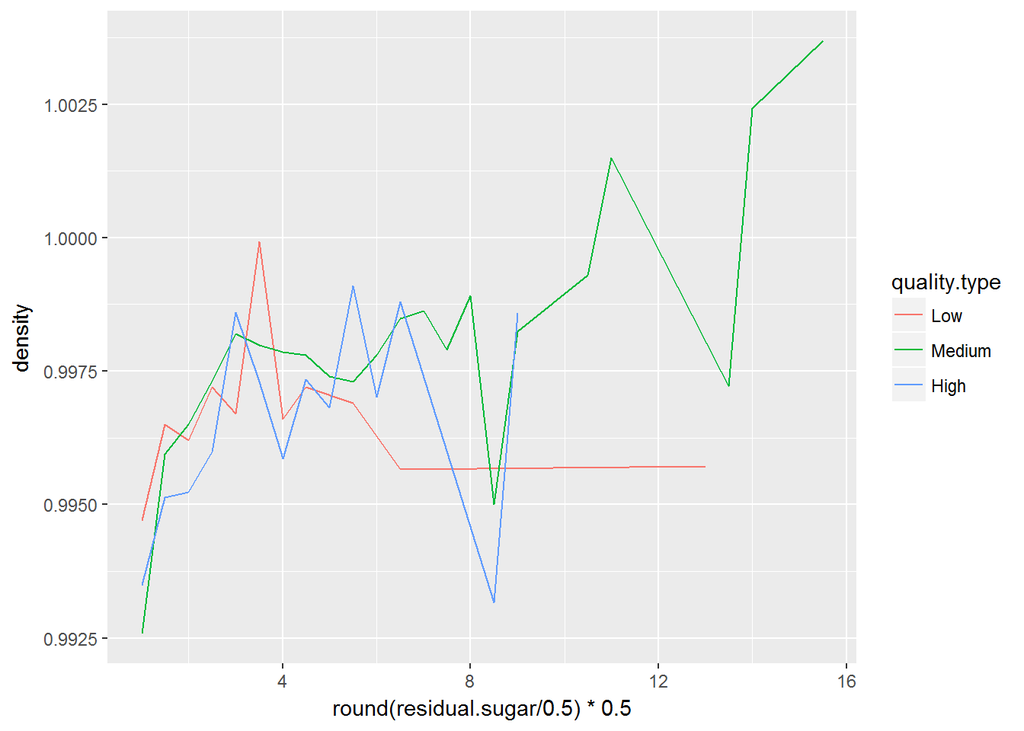

After adjusting for residual sugar, high quality wines tend to be less dense compared to medium quality wines but is split 50-50 between low quality wines.

We saw that higher pH was associated with higher wine quality, but this may be due to that higher quality wines have higher acid content.

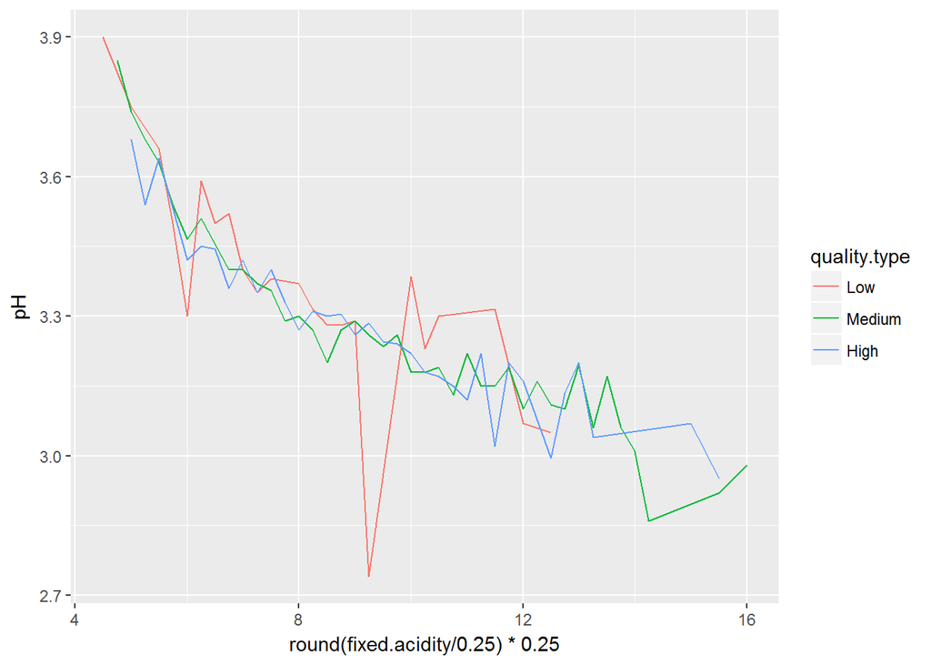

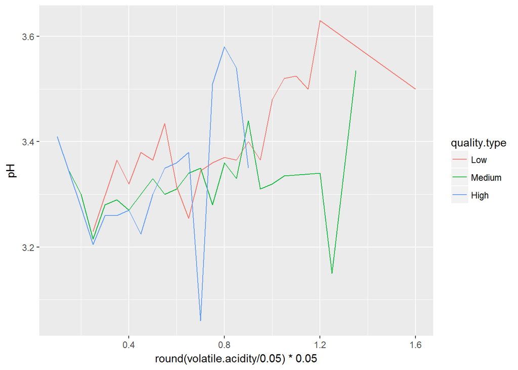

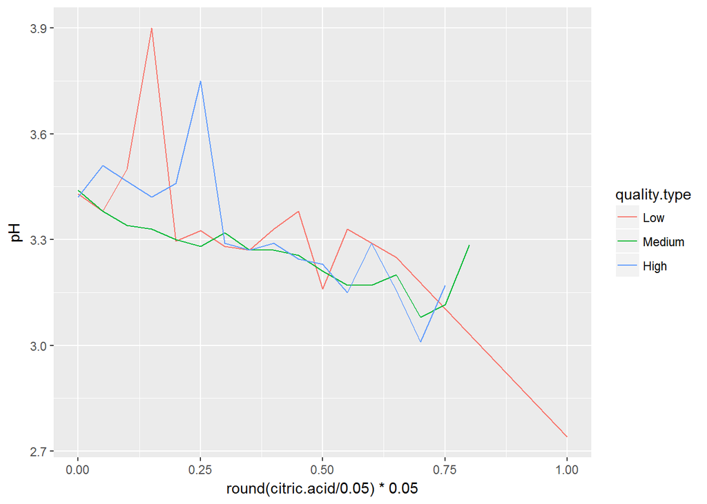

After adjusting for acid content, it’s apparent that pH does not affect wine quality.

In bivariate analysis we didn’t see a straight forward relationship between chlorides and wine quality. We saw that chlorides have weak to weak-moderate correlations with citric acid, alcohol, sulphates, density, and pH. We know that pH and density doesn’t affect wine quality, but citric acid, alcohol, and sulphates do.

We will check what happens with chlorides when we adjust for each of these 3 variables.

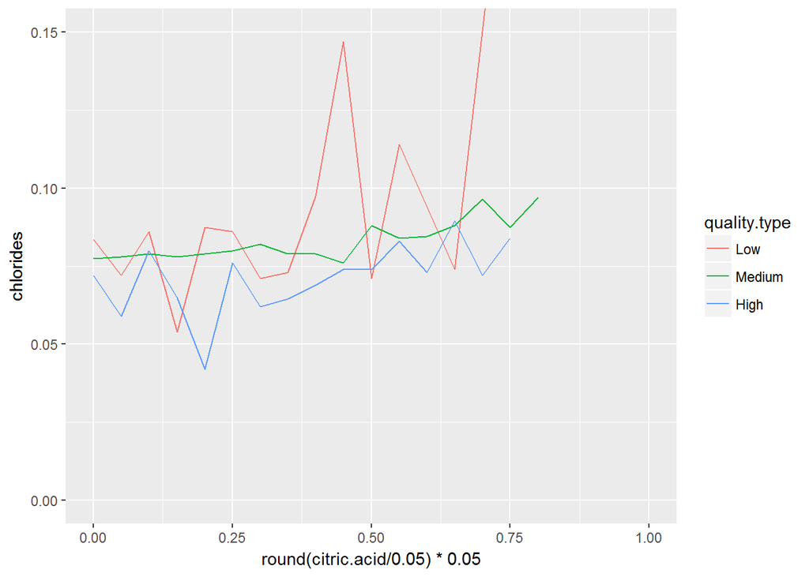

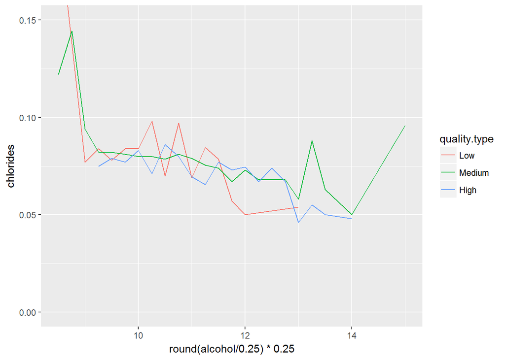

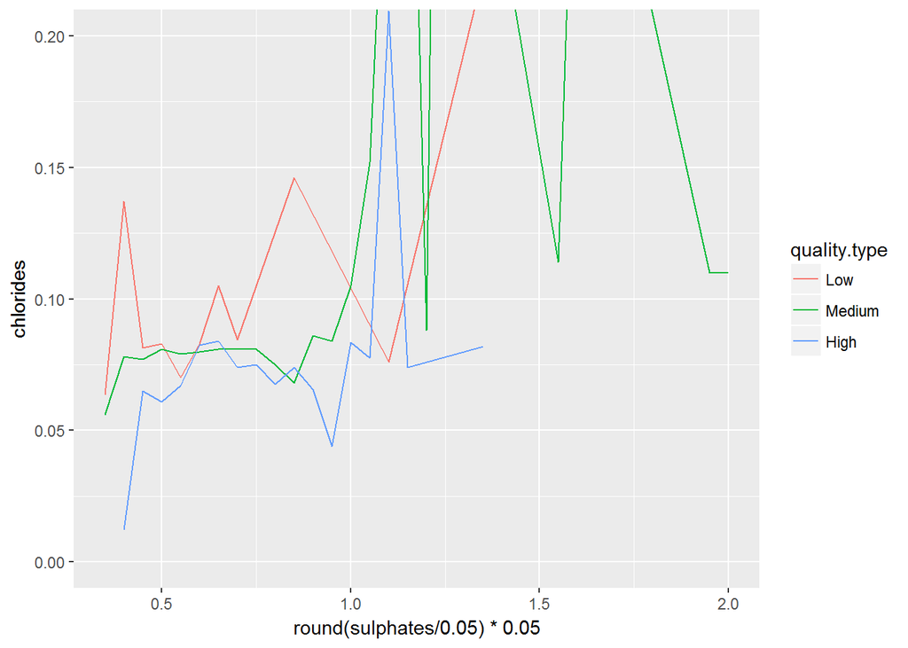

After adjusting for citric acid, we find that higher quality wines have less chlorides.

After adjusting for alcohol, there is no clear relationship

After adjusting for sulphates, we find that higher quality wine have less chlorides.

# Multivariate Analysis

### Talk about some of the relationships you observed

High quality wine on average exhibit a total sulfur dioxide of between 15 to 50 depending on the ratio of free sulfur dioxide to total sulfur dioxide which should be between 0.15 and 0.75.

Adjusting for each of the three acids, we find that high quality wine is indeed associated with low volatile acidity, high fixed acidity, and high citric acid content.

In bivariate analysis we saw a clear trend that high quality wine was less dense compared to lower qualities. Here, we found that after adjusting for residual sugar, it is less dense compared to medium quality wines but only less dense half the time when compared to low quality wine.

After adjusting for acid content, pH does not affect wine quality

After adjusting for citric acid and sulphates, we find that high quality wine are associated with lower amounts of chloride.

# Final Plots and Summary

### Plot One

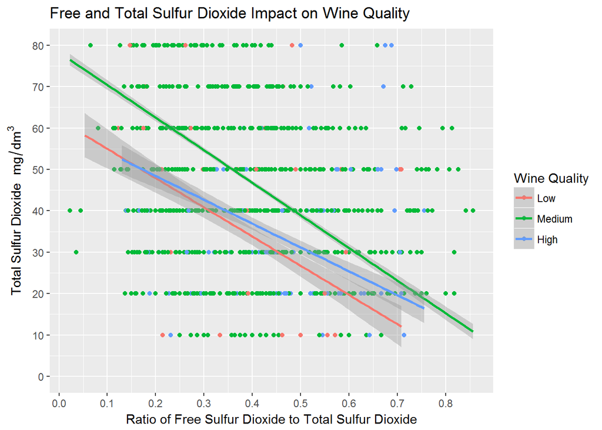

### Description One

The plot shows the ideal total sulfur dioxide content in the wine based on the ratio of free sulfur dioxide to total sulfur dioxide.

### Plot Two

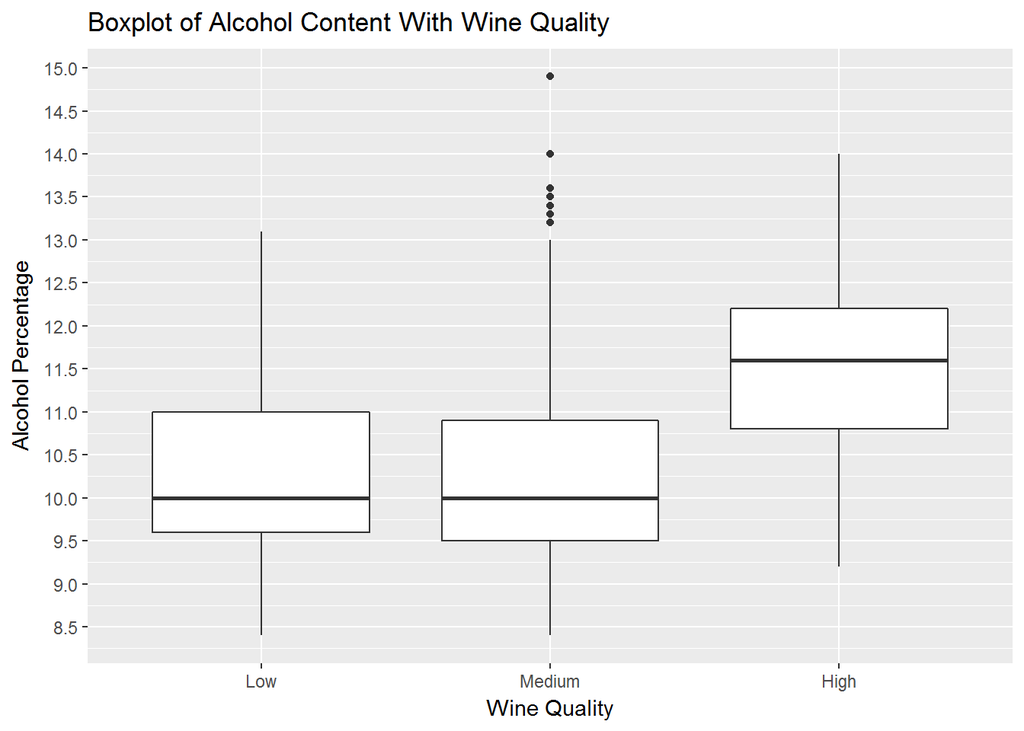

### Description Two

This plot clearly shows that the majority of high quality wine have higher alcohol content compared to lower quality wine.

### Plot Three

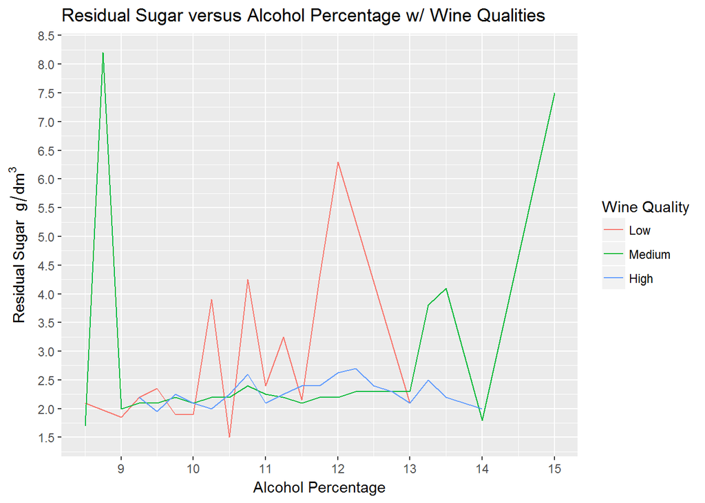

# Reflection

I started data exploration with univariate analysis on each chemical attribute of red wine. The data was tidy and each column had the correct data type.I found the distribution of every variable and under quality, I noticed that it could be separated into low, medium, and high quality wine based on the grouping of points.

Overall I noticed that the bivariate analysis is not completely reliable when you don’t adjust for certain variables. I did not look into every multivariate plot possible to see if there were other variables found to have a certain relationship under bivariate change under multivariate conditions.

There are several limitations to this analysis. The first one is that the way I defined the wine quality does not necessarily represent the high, medium, and low wine qualities, so trends found only rely on the original definition. High quality wine is rated 7 or 8. Medium quality is 5 or 6. Low quality is 3 or 4. The second limitation is that the data contains only Portugeuse “Vinho Verde” red wines, so the conclusions and trends found here only apply to those group of wines and not red wines in general. Another limitation could be the presence of lurking variables. For an example, the age of the wine could impact wine quality.There were also a lot of medium quality wine but not a lot of high quality wine or low quality wine, so the observations for some of the plots may have occurred due to chance.

For future work with this dataset, more multivariate analysis can be done. Instead of looking at just the different quality of wine, you could separate other variables into groups and compare it with quality and another variable. More variables could be included such as ratios between variables and create more complex visualizations that plot between two different ratios and find the ideal ratio of certain attributes. It could be the case that some attributes are not simple in that more is always better or less is always better. We saw that with free sulfur dioxide. We also saw that the three acid attributes were correlated with each other. Statistical models can also be created or machine learning models to predict wine quality based on the chemical attributes. Bootstrapping could be applied to the dataset to achieve higher counts of low quality and high quality wine. This could potentially change some of the trends found in this analysis.